# Homework 11

Solutions will be available after Monday, November 9, 2026.

## Question 1: Implementing K-means

K-means is a relatively simple algorithm that we can write ourselves. For Questions 1 and 2, do not use an existing function that performs K-means directly.

Generate 10 observations with two independent standard normal coordinates. Set a random seed and report it. Randomly assign the observations to $K=2$ clusters, making sure neither cluster is empty. Let $C(i)$ denote the cluster assigned to observation $x_i$, and let $m_k$ denote the mean of cluster $k$.

1. Perform one iteration: calculate the cluster means, then assign each observation to its closest mean using Euclidean distance. Report the means and updated assignments, and plot the observations colored by their updated assignments.

   **Show the workflow**

   ```r
   # Source: Week 11 Lecture: K-Means
   set.seed(43201)
   print("The seed is 43201.")
   ```

   ```
   [1] "The seed is 43201."
   ```

   **Show the workflow**

   ```r
   # Generate 10 observations with two independent standard normal coordinates
   data <- matrix(rnorm(n = 20, mean = 0, sd = 1), nrow = 10, ncol = 2)

   # Randomly assign points into clusters 1 or 2
   # Use C(i) to denote the clusters; make sure neither cluster is empty
   C <- sample(1:2, size = 10, replace = TRUE)
   while(sum(C == 1) == 0 | sum(C == 2) == 0){
     C <- sample(1:2, size = 10, replace = TRUE)
   }

   # Calculate cluster means
   m1 <- colMeans(data[C == 1, , drop = FALSE])
   m2 <- colMeans(data[C == 2, , drop = FALSE])
   mk <- rbind(m1, m2)

   # Calculate the distances between the observations and the cluster means
   # MARGIN = 2 means to apply the fuction to each column
   # sweep subtracts mean coordinates from columns and squares the differences
   # rowSums adds the x1 and x2 coordinates together per observation
   distances <- sapply(1:2, function(k){
     rowSums(sweep(data, MARGIN = 2, mk[k, ])^2)
   })

   # Assign each observation to its closest mean using Euclidean distance
   # MARGIN = 1 means to apply the function to each row
   C <- apply(distances, MARGIN = 1, which.min)

   # Report means and updated assignments
   mk
   ```

   ```
            [,1]        [,2]
   m1 0.28368565 -0.40874925
   m2 0.01721702  0.04682711
   ```

   **Show the workflow**

   ```r
   C
   ```

   ```
    [1] 2 1 2 1 2 2 1 1 2 1
   ```

   **Show the workflow**

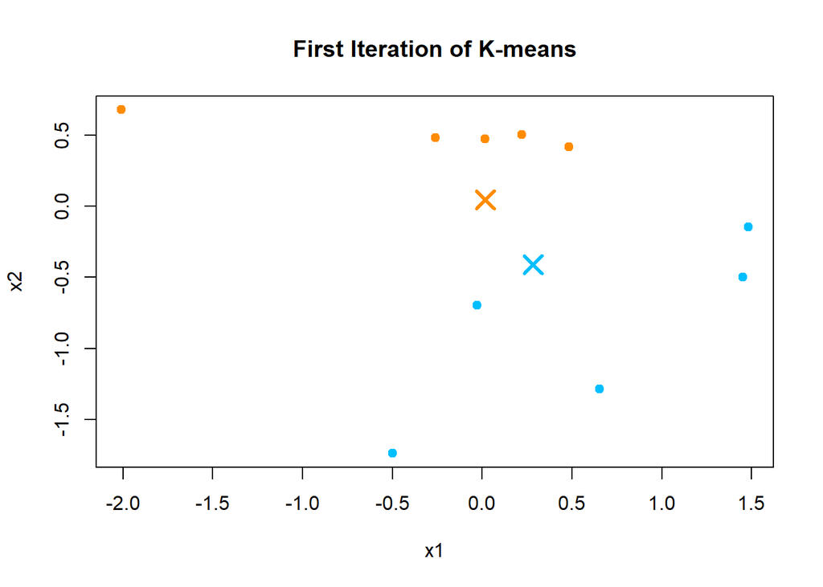

   ```r
   # Plot observations colored by their updated assignments
   cluster_colors <- c("deepskyblue", "darkorange")
   plot(data,
        main = "First Iteration of K-means", xlab = "x1", ylab = "x2",
        pch = 19,
        cex = 1,
        col = cluster_colors[C])
   points(mk, pch = 4, cex = 2, lwd = 3, col = cluster_colors)
   ```

2. Write a function that repeats these two steps until the assignments stop changing or a specified maximum number of iterations is reached. Your function should work for a data matrix with any number of variables and a chosen number of clusters $K$. Start from a nonempty assignment to each cluster; if a cluster becomes empty during iteration, keep its previous mean. Recalculate the cluster means from the final assignments before returning them. Return the final assignments, cluster means, and within-cluster sum of squares,

   $$\sum_{k=1}^K\sum_{i:\,C(i)=k}\lVert x_i-m_k\rVert^2.$$

   **Show the workflow**

   ```r
   set.seed(43201)
   k_means <- function(x, k, max_iter){
     n <- nrow(x)

     # Initialize setup
     # Randomly assign points into clusters k
     # Redraw until every cluster has at least one point
     C <- sample(1:k, size = n, replace = TRUE)
     while(any(tabulate(C, nbins = k) == 0)){
       C <- sample(1:k, size = n, replace = TRUE)
     }

     mk <- matrix(NA_real_, nrow = k, ncol = ncol(x))

     for (iter in seq_len(max_iter)){

       old_C <- C

       # Count how many observations are assigned to each cluster
       cluster_sizes <- tabulate(C, nbins = k)
       empty_clusters <- which(cluster_sizes == 0)

       # Calculate cluster means
       # If a cluster becomes empty during iteration, keep its previous mean
       for (i in seq_len(k)){
         if (cluster_sizes[i] > 0){
           mk[i, ] <- colMeans(x[C == i, , drop = FALSE])
         }
       }

       # Calculate the distances between the observations and the cluster means
       distances <- sapply(seq_len(k), function(i){
         rowSums(sweep(x, MARGIN = 2, mk[i, ])^2)
       })

       # Assign each observation to its closest mean using Euclidean distance
       C <- apply(distances, MARGIN = 1, which.min)

       # Check if assignments stopped changing
       if (all(C == old_C)){
         break
       }
     }

     # Recalculate means from final assignments
     cluster_sizes <- tabulate(C, nbins = k)
     for (i in seq_len(k)){
       if (cluster_sizes[i] > 0){
         mk[i, ] <- colMeans(x[C == i, , drop = FALSE])
       }
     }

     # Calculate witihn-cluster sums of squares
     within_cluster_ss <- sum(rowSums((x - mk[C, , drop = FALSE])^2))

     # Report final assignments, cluster means, and within-cluster sums of squares
     return(list(
       assignments = C,
       means = mk,
       within_cluster_ss = within_cluster_ss
     ))

   }
   ```

3. Apply your function to the same 10 observations from two different random initial assignments. Report the final plots, cluster means, and within-cluster sums of squares. Do the two runs produce the same grouping and objective value? Explain your findings.

   **Show the workflow**

   ```r
   results1 <- k_means(data, k = 2, max_iter = 100)
   results1
   ```

   ```
   $assignments
    [1] 1 2 1 2 1 1 2 2 1 2

   $means
              [,1]       [,2]
   [1,] -0.3102515  0.5103803
   [2,]  0.6111541 -0.8723025

   $within_cluster_ss
   [1] 8.66793
   ```

   **Show the workflow**

   ```r
   results2 <- k_means(data, k = 2, max_iter = 100)
   results2
   ```

   ```
   $assignments
    [1] 1 1 2 1 2 2 1 1 2 2

   $means
              [,1]        [,2]
   [1,]  0.8080295 -0.44139129
   [2,] -0.5071269  0.07946915

   $within_cluster_ss
   [1] 10.5676
   ```

   **Show the workflow**

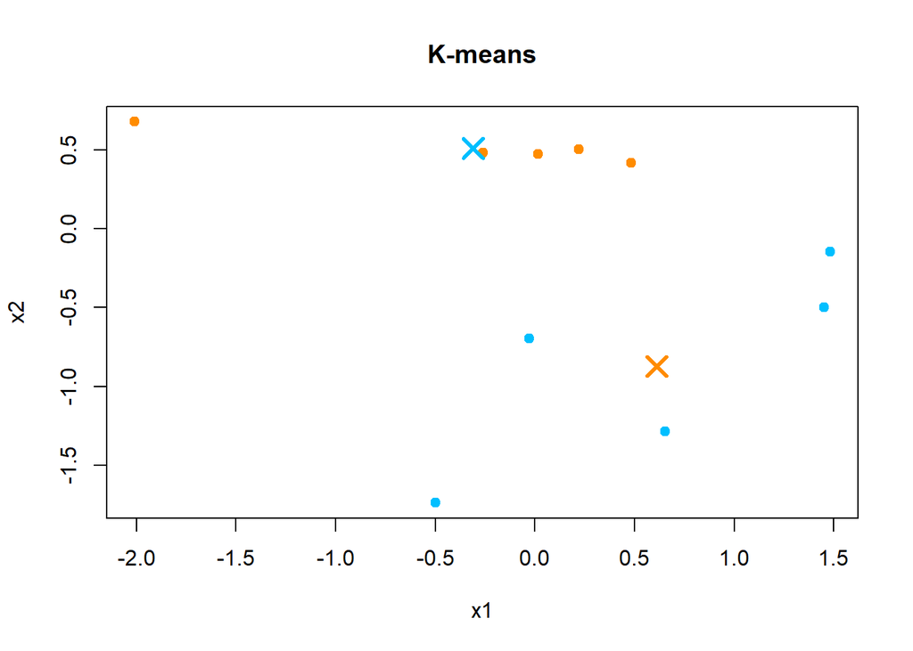

   ```r
   # Plot observations colored by their updated assignments
   plot(data,
        main = "K-means", xlab = "x1", ylab = "x2",
        pch = 19,
        cex = 1,
        col = cluster_colors[C])
   points(results1$means, pch = 4, cex = 2, lwd = 3, col = cluster_colors)
   ```

   **Show the workflow**

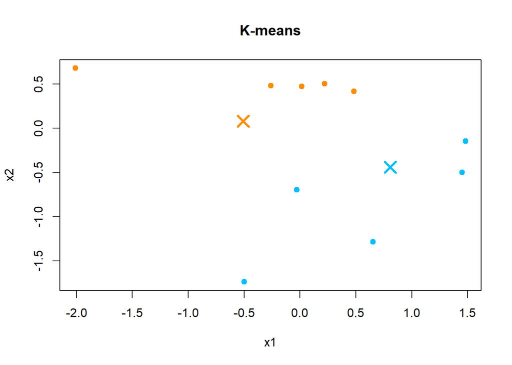

   ```r
   plot(data,
        main = "K-means", xlab = "x1", ylab = "x2",
        pch = 19,
        cex = 1,
        col = cluster_colors[C])
   points(results2$means, pch = 4, cex = 2, lwd = 3, col = cluster_colors)
   ```

## Question 2: Image color compression

Pick your favorite color image and use your K-means function from Question 1 to cluster its pixels. For computational efficiency, resize the image to no more than $200\times200$ pixels and use its three RGB color channels.

1. Plot the original image and report its dimensions. Transform it into a data matrix with one observation per pixel and three variables: red, green, and blue. Report the dimensions of this matrix.

   The original image has been plotted since the resized image is too pixelated to see clearly. Dimensions for both the original and resized images are reported.

   **Show the workflow**

[figure not shown]

   ```r
   # Source: Week 11 Lecture: K-Means
   # Import png image
   library(png)
   original_img <- readPNG("data/painted_inazuma_city_Vigamox.png")

   # Plot the original image (reszied image is too pixelated to see clearly)
   plot.new()
   plot.window(xlim = c(0, 1), ylim = c(0, 1), xaxs = "i", yaxs = "i")
   rasterImage(original_img, 0, 0, 1, 1)
   ```

   **Show the workflow**

   ```r
   dim(original_img)
   ```

   ```
   [1]  464 1080    3
   ```

   **Show the workflow**

   ```r
   # After resizing, report its dimensions
   img <- readPNG("data/painted_inazuma_city_Vigamox_resized.png")
   dim(img)
   ```

   ```
   [1]  86 200   3
   ```

   **Show the workflow**

   ```r
   # Vectorize each red, green, and blue layer in column order
   img_expand <- apply(img, 3, c)
   dim(img_expand)
   ```

   ```
   [1] 17200     3
   ```

2. For $K=2,3,5,10$, apply your function to the pixel data. Report the cluster means and within-cluster sum of squares for each $K$. Reconstruct and plot each compressed image by replacing every pixel with its assigned cluster mean. Use the same RGB scale for all fits.

   **Show the workflow**

   ```r
   # Apply function to pixel data
   fit1 <- k_means(img_expand, k = 2, max_iter = 100)
   fit2 <- k_means(img_expand, k = 3, max_iter = 100)
   fit3 <- k_means(img_expand, k = 5, max_iter = 100)
   fit4 <- k_means(img_expand, k = 10, max_iter = 100)

   # Report cluster means and within-cluster sum of squares for each K
   fits <- list(
     "2" = fit1,
     "3" = fit2,
     "5" = fit3,
     "10" = fit4
   )

   results_table <- do.call(rbind, lapply(names(fits), function(k){
     fit <- fits[[k]]

     data.frame(
       k = as.integer(k),
       cluster = seq_len(nrow(fit$means)),
       red = fit$means[, 1],
       green = fit$means[, 2],
       blue = fit$means[, 3],
       within_cluster_ss = fit$within_cluster_ss
     )
   }))

   results_table
   ```

   ```
       k cluster       red     green      blue within_cluster_ss
   1   2       1 0.2413035 0.2323608 0.3293274          610.0206
   2   2       2 0.6951590 0.5240075 0.8162453          610.0206
   3   3       1 0.4113426 0.3306362 0.5102160          322.1721
   4   3       2 0.7190175 0.5418815 0.8451617          322.1721
   5   3       3 0.1627345 0.1871368 0.2416195          322.1721
   6   5       1 0.1396984 0.1691144 0.2106383          182.9710
   7   5       2 0.6547863 0.5211180 0.8389940          182.9710
   8   5       3 0.2886497 0.2699649 0.3935467          182.9710
   9   5       4 0.8507481 0.5894719 0.8665019          182.9710
   10  5       5 0.4743171 0.3617322 0.5680964          182.9710
   11 10       1 0.6511790 0.5630742 0.8724964          115.4779
   12 10       2 0.3557119 0.2941176 0.4449144          115.4779
   13 10       3 0.4370110 0.3366324 0.5536430          115.4779
   14 10       4 0.5413833 0.4158329 0.6616585          115.4779
   15 10       5 0.8602218 0.5993896 0.8726661          115.4779
   16 10       6 0.3538244 0.3919449 0.6018195          115.4779
   17 10       7 0.6083503 0.3852787 0.5067607          115.4779
   18 10       8 0.1292731 0.1605467 0.1958591          115.4779
   19 10       9 0.2300084 0.2399805 0.3359622          115.4779
   20 10      10 0.6874826 0.4614617 0.7977897          115.4779
   ```

   **Show the workflow**

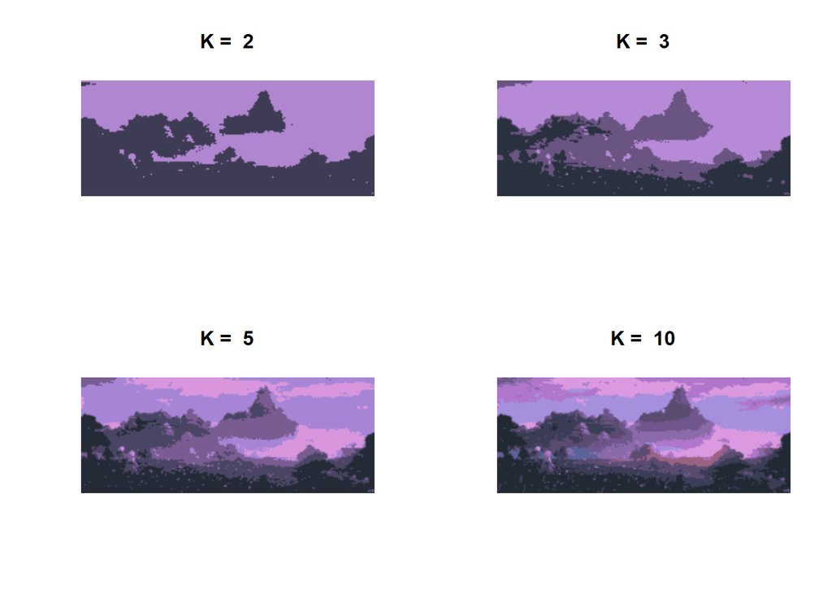

   ```r
   # Replace every pixel with its assigned cluster mean
   img_rbg <- img[, , 1:3]
   fits1 <- list(fit1, fit2, fit3, fit4)

   par(mfrow = c(2, 2))

   for (fit in fits){

     # Replace each pixel with the mean of its assigned cluster
     # fit$assignments gives each pixel's cluser label
     # fit$means contains the RGB mean for each cluster
     compressed_pixels <- fit$means[fit$assignments, , drop = FALSE]

     # Reshape the pixel rows into height x width x 3
     compressed_img <- array(compressed_pixels, dim = dim(img_rbg))

     # Plot each compressed image
     plot.new()
     plot.window(xlim = c(0, 1), ylim = c(0, 1), xaxs = "i", yaxs = "i")
     rasterImage(compressed_img, 0, 0, 1, 1)
     title(main = paste("K = ", nrow(fit$means)))
   }
   ```

3. Which value of $K$ would you choose for this image? Briefly justify your choice using the reconstructed images and the within-cluster sums of squares.

   I would choose $K = 10$ because the reconstructed image has more colors and shapes than the other images. The images for $K = 2$ and $K = 3$ are flat, and it is difficult to tell what the image is supposed to be. The image for $K = 5$ has more detail, but the image for $K = 10$ has more details and color variation. In addition, $K = 10$ has the lowest within-cluster sum of squares compared to the other $K$ values.

## Question 3: Hierarchical clustering of cars

The file `data/mtcars.csv` contains 11 numerical variables for 32 cars, including fuel economy, horsepower, and weight. The `car` column gives the model names; use it to label observations, not as a clustering variable. You may use existing hierarchical clustering functions for this question.

1. Standardize each numerical variable to have mean 0 and standard deviation 1. Using Euclidean distance, perform hierarchical clustering with single, complete, and average linkage. Plot the three dendrograms with the car names and compare the results.

   **Show the workflow**

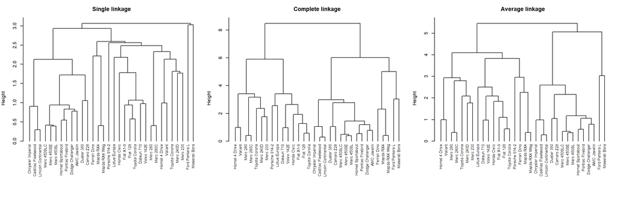

   ```r
   # Source: Week 11 Lecture: Hierarchical Clustering
   # Load the data
   df_mtcars <- read.csv("data/mtcars.csv")

   X_cars <- df_mtcars[, -1]
   y_cars <- df_mtcars$car

   # Standardize each variable to have mean 0 and sd 1
   X_cars_scaled <- scale(X_cars, center = TRUE, scale = TRUE)

   # Use Euclidean distance to perform hierarchial clustering
   hcfit1 <- hclust(dist(X_cars_scaled, method = "euclidean"),
                    method = "single")
   hcfit2 <- hclust(dist(X_cars_scaled, method = "euclidean"),
                    method = "complete")
   hcfit3 <- hclust(dist(X_cars_scaled, method = "euclidean"),
                    method = "average")

   # Plot the three dendrograms with car names
   # mar = c(bottom, left, top, right): controls plot margins in lines of text
   par(mfrow = c(1, 3), mar = c(7, 4, 3, 1))

   # hang = -1 makes the leaves line up at the bottom
   plot(hcfit1, hang = -1, labels = y_cars,
        main = "Single linkage", xlab = "", sub = "",
        cex = 0.8)
   plot(hcfit2, hang = -1, labels = y_cars,
        main = "Complete linkage", xlab = "", sub = "",
        cex = 0.8)
   plot(hcfit3, hang = -1, labels = y_cars,
        main = "Average linkage", xlab = "", sub = "",
        cex = 0.8)
   ```

2. Choose one linkage method and a number of clusters that you consider reasonable. Report the cluster memberships and a table of cluster means on the original variable scales. Describe the main characteristics of the groups and explain your choice using the dendrogram and table. Briefly explain why standardizing the variables matters for this analysis.

   **Show the workflow**

   ```r
   car_clusters <- cutree(hcfit2, k = 4)

   # Car names grouped by cluster
   split(y_cars, car_clusters)
   ```

   ```
   $`1`
   [1] "Mazda RX4"      "Mazda RX4 Wag"  "Ford Pantera L" "Ferrari Dino"
   [5] "Maserati Bora"

   $`2`
   [1] "Datsun 710"     "Fiat 128"       "Honda Civic"    "Toyota Corolla"
   [5] "Fiat X1-9"      "Porsche 914-2"  "Lotus Europa"   "Volvo 142E"

   $`3`
   [1] "Hornet 4 Drive" "Valiant"        "Merc 240D"      "Merc 230"
   [5] "Merc 280"       "Merc 280C"      "Toyota Corona"

   $`4`
    [1] "Hornet Sportabout"   "Duster 360"          "Merc 450SE"
    [4] "Merc 450SL"          "Merc 450SLC"         "Cadillac Fleetwood"
    [7] "Lincoln Continental" "Chrysler Imperial"   "Dodge Challenger"
   [10] "AMC Javelin"         "Camaro Z28"          "Pontiac Firebird"
   ```

   **Show the workflow**

   ```r
   # Calculate the cluster means on the original variable scales
   cluster_means <- aggregate(
     X_cars, # original and unscaled measurements
     by = list(cluster = car_clusters), # groups cars according to cutree()
     FUN = mean # calculates each variable's mean within each group
   )
   cluster_means
   ```

   ```
     cluster      mpg      cyl     disp       hp     drat       wt     qsec    vs
   1       1 18.50000 6.800000 223.4000 198.8000 3.836000 3.001000 15.61600 0.000
   2       2 28.07500 4.000000  93.6125  81.8750 4.183750 2.042250 18.45000 0.875
   3       3 20.74286 5.142857 175.1143 102.1429 3.570000 3.194286 19.96714 1.000
   4       4 15.05000 8.000000 357.6167 194.1667 3.120833 4.104083 17.14250 0.000
     am     gear     carb
   1  1 4.600000 5.200000
   2  1 4.250000 1.500000
   3  0 3.571429 2.142857
   4  0 3.000000 3.083333
   ```

   The groups have relatively close average `drat`, `qsec`, and `gear`, and they have different averages for `mpg`, `cyl`, `wt`, `disp`, `hp`, and `carb`. Cluster 2 has the lowest average for `disp` and `hp`, but they have the highest average `mpg` (these cars have better fuel economy, but they have less power). Clusters with higher averages of `disp` and `hp` generally have lower `mpg` averages.

   Based on the dendrograms above, the complete linkage graph showed a large height gap compared to single linkage and average linkage. The complete linkage dendrogram has a large jump in height at $K = 4$. The `cluster_mean` table illustrates differences in group means for variables `mpg`, `disp`, and `wt`. Therefore, the complete linkage method with $K = 4$ clusters is reasonable.

   Standardizing the variables matters for this analysis because Euclidean distance depends on the scale and magnitude of the variables. Without standardization, variables with large magnitudes and ranges could dominate the clustering.